# XGBOOSTED Model - MSBA Capstone

Jacob Jarrard U0082542

05 November 2023

> In order to get the below files you have to run my “cleaning and engineering.Rmd”

```r
x_train_tbl <- read.csv("x_train_tbl.csv")
y_train_tbl <- read.csv("y_train_tbl.csv")
x_test_tbl <- read.csv("x_test_tbl.csv")


# Adding TARGET column back to scaled_x_train_tbl
final_train_tbl <- cbind(x_train_tbl, TARGET = y_train_tbl$TARGET)
final_train_tbl <- final_train_tbl %>%
  select(-SK_ID_CURR)
str(final_train_tbl)
```

```
## 'data.frame':    307511 obs. of  68 variables:
##  $ NAME_CONTRACT_TYPE         : chr  "Cash loans" "Cash loans" "Revolving loans" "Cash loans" ...
##  $ CODE_GENDER                : chr  "M" "F" "M" "F" ...
##  $ FLAG_OWN_CAR               : chr  "N" "N" "Y" "N" ...
##  $ FLAG_OWN_REALTY            : chr  "Y" "N" "Y" "Y" ...
##  $ CNT_CHILDREN               : int  0 0 0 0 0 0 1 0 0 0 ...
##  $ AMT_INCOME_TOTAL           : num  202500 270000 67500 135000 121500 ...
##  $ AMT_CREDIT                 : num  406598 1293502 135000 312682 513000 ...
##  $ AMT_ANNUITY                : num  24700 35698 6750 29686 21866 ...
##  $ AMT_GOODS_PRICE            : num  351000 1129500 135000 297000 513000 ...
##  $ NAME_TYPE_SUITE            : chr  "Unaccompanied" "Family" "Unaccompanied" "Unaccompanied" ...
##  $ NAME_INCOME_TYPE           : chr  "Working" "State servant" "Working" "Working" ...
##  $ NAME_EDUCATION_TYPE        : chr  "Secondary / secondary special" "Higher education" "Secondary / secondary special" "Secondary / secondary special" ...
##  $ NAME_FAMILY_STATUS         : chr  "Single / not married" "Married" "Single / not married" "Civil marriage" ...
##  $ NAME_HOUSING_TYPE          : chr  "House / apartment" "House / apartment" "House / apartment" "House / apartment" ...
```

[output cut: 54 more lines]

```r
# Selecting the desired columns for training data
final_train_tbl <- final_train_tbl %>%
  select(
    AMT_CREDIT,
    CNT_CHILDREN,
    NAME_FAMILY_STATUS,
    AMT_INCOME_TOTAL,
    CODE_GENDER,
    DAYS_BIRTH,
    DAYS_EMPLOYED,
    FLAG_PHONE,
    EXT_SOURCE_1,
    EXT_SOURCE_2,
    EXT_SOURCE_3,
    ORGANIZATION_TYPE,
    NAME_EDUCATION_TYPE,
    REGION_POPULATION_RELATIVE,
    FLAG_OWN_CAR,
    OWN_CAR_AGE,
    AMT_REQ_CREDIT_BUREAU_YEAR,
    OCCUPATION_TYPE,
    REG_CITY_NOT_LIVE_CITY,
    REGION_RATING_CLIENT,
    OBS_30_CNT_SOCIAL_CIRCLE,
    TARGET
  )
```

```r
#ONE HOT ENCODE TRAINING SET


char_cols <- sapply(final_train_tbl, is.character)
final_train_tbl[char_cols] <- lapply(final_train_tbl[char_cols], factor)

# Create a dummyVars object to one-hot encode the data
# Note: use all.factor.levels = TRUE to ensure all levels are included
dummies <- dummyVars(" ~ .", data = final_train_tbl, all.factor.levels = TRUE)

# Create the full model matrix with one-hot encoded categorical variables
final_train_tbl_encoded <- predict(dummies, newdata = final_train_tbl)

# Convert to a data frame
final_train_tbl_encoded <- as.data.frame(final_train_tbl_encoded)

# Verify the structure of the new dataset
str(final_train_tbl_encoded)
```

```
## 'data.frame':    307511 obs. of  50 variables:
##  $ AMT_CREDIT                                       : num  406598 1293502 135000 312682 513000 ...
##  $ CNT_CHILDREN                                     : num  0 0 0 0 0 0 1 0 0 0 ...
##  $ NAME_FAMILY_STATUS.Civil marriage                : num  0 0 0 1 0 0 0 0 0 0 ...
##  $ NAME_FAMILY_STATUS.Married                       : num  0 1 0 0 0 1 1 1 1 0 ...
##  $ NAME_FAMILY_STATUS.Separated                     : num  0 0 0 0 0 0 0 0 0 0 ...
##  $ NAME_FAMILY_STATUS.Single / not married          : num  1 0 1 0 1 0 0 0 0 1 ...
##  $ NAME_FAMILY_STATUS.Widow                         : num  0 0 0 0 0 0 0 0 0 0 ...
##  $ AMT_INCOME_TOTAL                                 : num  202500 270000 67500 135000 121500 ...
##  $ CODE_GENDER.F                                    : num  0 1 0 1 0 0 1 0 1 0 ...
##  $ CODE_GENDER.M                                    : num  1 0 1 0 1 1 0 1 0 1 ...
##  $ DAYS_BIRTH                                       : num  -9461 -16765 -19046 -19005 -19932 ...
##  $ DAYS_EMPLOYED                                    : num  -637 -1188 -225 -3039 -3038 ...
##  $ FLAG_PHONE                                       : num  1 1 1 0 0 1 1 0 0 0 ...
##  $ EXT_SOURCE_1                                     : num  0.083 0.311 0 0 0 ...
```

[output cut: 36 more lines]

```r
# Selecting the desired columns from the dataset
final_test_tbl <- x_test_tbl %>%
  select(
    AMT_CREDIT,
    CNT_CHILDREN,
    NAME_FAMILY_STATUS,
    AMT_INCOME_TOTAL,
    CODE_GENDER,
    DAYS_BIRTH,
    DAYS_EMPLOYED,
    FLAG_PHONE,
    EXT_SOURCE_1,
    EXT_SOURCE_2,
    EXT_SOURCE_3,
    ORGANIZATION_TYPE,
    NAME_EDUCATION_TYPE,
    REGION_POPULATION_RELATIVE,
    FLAG_OWN_CAR,
    OWN_CAR_AGE,
    AMT_REQ_CREDIT_BUREAU_YEAR,
    OCCUPATION_TYPE,
    REG_CITY_NOT_LIVE_CITY,
    REGION_RATING_CLIENT,
    OBS_30_CNT_SOCIAL_CIRCLE
  )

#doing the same to testing set
str(final_test_tbl)
```

```
## 'data.frame':    48744 obs. of  21 variables:
##  $ AMT_CREDIT                : num  568800 222768 663264 1575000 625500 ...
##  $ CNT_CHILDREN              : int  0 0 0 2 1 0 2 0 0 1 ...
##  $ NAME_FAMILY_STATUS        : chr  "Married" "Married" "Married" "Married" ...
##  $ AMT_INCOME_TOTAL          : num  135000 99000 202500 315000 180000 ...
##  $ CODE_GENDER               : chr  "F" "M" "M" "F" ...
##  $ DAYS_BIRTH                : int  -19241 -18064 -20038 -13976 -13040 -18604 -16685 -9516 -12744 -10395 ...
##  $ DAYS_EMPLOYED             : int  -2329 -4469 -4458 -1866 -2191 -12009 -2580 -1387 -1013 -2625 ...
##  $ FLAG_PHONE                : int  0 0 0 1 0 1 0 1 0 1 ...
##  $ EXT_SOURCE_1              : num  0.753 0.565 0 0.526 0.202 ...
##  $ EXT_SOURCE_2              : num  0.79 0.292 0.7 0.51 0.426 ...
##  $ EXT_SOURCE_3              : num  0.16 0.433 0.611 0.613 1 ...
##  $ ORGANIZATION_TYPE         : int  4 2 1 2 2 4 4 2 5 4 ...
##  $ NAME_EDUCATION_TYPE       : chr  "Higher education" "Secondary / secondary special" "Higher education" "Secondary / secondary special" ...
##  $ REGION_POPULATION_RELATIVE: num  0.0188 0.0358 0.0191 0.0264 0.01 ...
##  $ FLAG_OWN_CAR              : chr  "N" "N" "Y" "N" ...
##  $ OWN_CAR_AGE               : int  0 0 5 0 16 10 3 0 0 5 ...
##  $ AMT_REQ_CREDIT_BUREAU_YEAR: int  0 3 4 3 1 2 1 2 5 2 ...
##  $ OCCUPATION_TYPE           : chr  "unreported" "Low-skill Laborers" "Drivers" "Sales staff" ...
##  $ REG_CITY_NOT_LIVE_CITY    : int  0 0 0 0 0 0 0 0 0 0 ...
##  $ REGION_RATING_CLIENT      : int  2 2 2 2 2 2 2 2 1 2 ...
##  $ OBS_30_CNT_SOCIAL_CIRCLE  : int  0 0 0 0 0 0 1 0 0 4 ...
```

```r
#ONE HOT CODE TEST SET



# Convert character columns to factors to prepare for one-hot encoding
char_cols <- sapply(final_test_tbl, is.character)
final_test_tbl[char_cols] <- lapply(final_test_tbl[char_cols], factor)

# Create a dummyVars object to one-hot encode the data
# Note: We use all.factor.levels = TRUE to ensure all levels are included
dummies <- dummyVars(" ~ .", data = final_test_tbl, all.factor.levels = TRUE)

# Create the full model matrix with one-hot encoded categorical variables
final_test_tbl_encoded <- predict(dummies, newdata = final_test_tbl)

# Convert to a data frame
final_test_tbl_encoded <- as.data.frame(final_test_tbl_encoded)

# Verify the structure of the new dataset
str(final_test_tbl_encoded)
```

```
## 'data.frame':    48744 obs. of  49 variables:
##  $ AMT_CREDIT                                       : num  568800 222768 663264 1575000 625500 ...
##  $ CNT_CHILDREN                                     : num  0 0 0 2 1 0 2 0 0 1 ...
##  $ NAME_FAMILY_STATUS.Civil marriage                : num  0 0 0 0 0 0 0 0 0 1 ...
##  $ NAME_FAMILY_STATUS.Married                       : num  1 1 1 1 1 1 1 0 1 0 ...
##  $ NAME_FAMILY_STATUS.Separated                     : num  0 0 0 0 0 0 0 0 0 0 ...
##  $ NAME_FAMILY_STATUS.Single / not married          : num  0 0 0 0 0 0 0 1 0 0 ...
##  $ NAME_FAMILY_STATUS.Widow                         : num  0 0 0 0 0 0 0 0 0 0 ...
##  $ AMT_INCOME_TOTAL                                 : num  135000 99000 202500 315000 180000 ...
##  $ CODE_GENDER.F                                    : num  1 0 0 1 0 1 0 0 1 1 ...
##  $ CODE_GENDER.M                                    : num  0 1 1 0 1 0 1 1 0 0 ...
##  $ DAYS_BIRTH                                       : num  -19241 -18064 -20038 -13976 -13040 ...
##  $ DAYS_EMPLOYED                                    : num  -2329 -4469 -4458 -1866 -2191 ...
##  $ FLAG_PHONE                                       : num  0 0 0 1 0 1 0 1 0 1 ...
##  $ EXT_SOURCE_1                                     : num  0.753 0.565 0 0.526 0.202 ...
```

[output cut: 35 more lines]

```r
# If you want to make a 80/20 split
#set.seed(123) # Setting a seed for reproducibility
#trainIndex <- createDataPartition(final_train_tbl_encoded$TARGET, p = 0.8,
 #                                 list = FALSE,
  #                                times = 1)

#trainSet <- final_train_tbl_encoded[trainIndex, ]
#testSet <- final_train_tbl_encoded[-trainIndex, ]

# Checking the dimensions of the split data
#dim(trainSet)
#dim(testSet)
```

```r
# Making the XGBoost
features <- final_train_tbl_encoded[, -which(names(final_train_tbl_encoded) == "TARGET")]
labels <- final_train_tbl_encoded$TARGET

# Convert to DMatrix
dtrain <- xgb.DMatrix(data = as.matrix(features), label = labels)

# Set XGBoost parameters
params <- list(
  booster = "gbtree",
  objective = "binary:logistic",
  eval_metric = "auc",
  eta = 0.1,
  gamma = 0,
  max_depth = 6,
  min_child_weight = 1,
  subsample = 0.8,
  colsample_bytree = 0.8
)

# Number of rounds for training
nrounds <- 100

# Train the model
model_xgb <- xgb.train(params = params, data = dtrain, nrounds = nrounds)

# Save the model (optional)
# xgb.save(model_xgb, "xgb_model.bin")

# dtest <- xgb.DMatrix(data = as.matrix(x_test_tbl_encoded))
# predictions <- predict(model_xgb, dtest)
```

```r
# Prepare the features and labels from the training set
train_features <- final_train_tbl_encoded[, -which(names(final_train_tbl_encoded) == "TARGET")]
train_labels <- final_train_tbl_encoded$TARGET

# Convert to DMatrix
dtrain <- xgb.DMatrix(data = as.matrix(train_features), label = train_labels)

# Assuming 'model_xgb' is your trained XGBoost model, predict on the training set
train_predictions_prob <- predict(model_xgb, dtrain)  # This gives you probabilities

# Convert probabilities to binary predictions using a threshold (default is 0.5)
train_predictions <- ifelse(train_predictions_prob > 0.5, 1, 0)

# Confusion matrix
confusion_matrix <- table(Predicted = train_predictions, Actual = train_labels)

# Print the confusion matrix
print(confusion_matrix)
```

```
##          Actual
## Predicted      0      1
##         0 282444  24292
##         1    242    533
```

```r
# Convert Actual and Predicted to factors if they are not already
train_labels_factor <- factor(train_labels, levels = c(0, 1))
train_predictions_factor <- factor(train_predictions, levels = c(0, 1))

# Create the confusion matrix using caret
cm <- confusionMatrix(train_predictions_factor, train_labels_factor)

# Print out the confusion matrix with statistics
print(cm)
```

```
## Confusion Matrix and Statistics
##
##           Reference
## Prediction      0      1
##          0 282444  24292
##          1    242    533
##
##                Accuracy : 0.9202
##                  95% CI : (0.9193, 0.9212)
##     No Information Rate : 0.9193
##     P-Value [Acc > NIR] : 0.02708
##
##                   Kappa : 0.0369
##
##  Mcnemar's Test P-Value : < 2e-16
##
##             Sensitivity : 0.99914
##             Specificity : 0.02147
##          Pos Pred Value : 0.92080
##          Neg Pred Value : 0.68774
##              Prevalence : 0.91927
##          Detection Rate : 0.91848
##    Detection Prevalence : 0.99748
##       Balanced Accuracy : 0.51031
##
##        'Positive' Class : 0
##
```

```r
# Load necessary libraries
library(caret)
library(pROC)
```

```r
library(xgboost)


# Calculate AUC and plot ROC Curve
roc_obj <- roc(response = train_labels_factor, predictor = train_predictions_prob)
auc_value <- auc(roc_obj)
cat("AUC:", auc_value, "\n")
```

```
## AUC: 0.780477
```

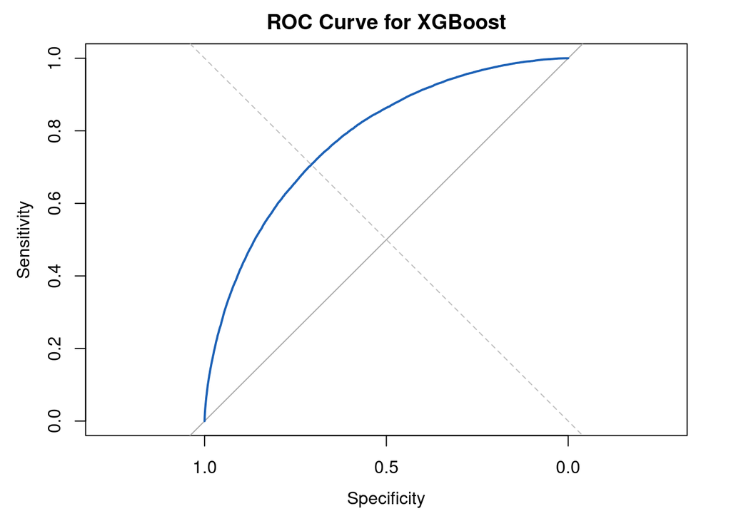

```r
# Plot the ROC curve
plot(roc_obj, main="ROC Curve for XGBoost", col="#1c61b6", lwd=2)
abline(a=0, b=1, lty=2, col="gray")
```

```r
# Calculate log loss
log_loss <- -mean(train_labels * log(train_predictions_prob) + (1 - train_labels) * log(1 - train_predictions_prob))
cat("Log Loss:", log_loss, "\n")
```

```
## Log Loss: 0.2395448
```

```r
# Prepare the features from the test set
test_features <- final_test_tbl_encoded

# Convert to DMatrix for xgboost
dtest <- xgb.DMatrix(data = as.matrix(test_features))

# Predict probabilities on the test set
predicted_probabilities <- predict(model_xgb, dtest)

# If you need binary predictions
# predicted_classes <- ifelse(predicted_probabilities > 0.5, 1, 0)

# Now, attach the SK_ID_CURR from x_test_tbl and combine with the predictions
prediction_tbl <- x_test_tbl %>%
  select(SK_ID_CURR) %>%
  mutate(TARGET = predicted_probabilities)  # Or use predicted_classes if you created it

# View the prediction table
head(prediction_tbl)
```

```
##   SK_ID_CURR     TARGET
## 1     100001 0.02391446
## 2     100005 0.08672381
## 3     100013 0.02851028
## 4     100028 0.04761773
## 5     100038 0.15102226
## 6     100042 0.04651530
```

```r
#write.csv(prediction_tbl, "submission_004.csv", row.names = FALSE)
```

> Kaggle here is .73894

```r
# weighting the minority class
# Calculate the proportion of negative to positive instances
table_of_target <- table(final_train_tbl_encoded$TARGET)

# Class "0" is the majority and "1" is the minority
scale_pos_weight_value <- table_of_target["0"] / table_of_target["1"]

# Print the scale_pos_weight_value
print(scale_pos_weight_value)
```

```
##        0
## 11.38715
```

> Try XGBoost again but with the minority class weight increased

```r
# Assuming x_train_tbl_encoded is your one-hot encoded training set
# Prepare the data
features <- final_train_tbl_encoded[, -which(names(final_train_tbl_encoded) == "TARGET")]
labels <- final_train_tbl_encoded$TARGET

# Calculate the ratio of negative to positive
ratio_neg_to_pos <- sum(labels == 0) / sum(labels == 1)

# Convert to DMatrix
dtrain <- xgb.DMatrix(data = as.matrix(features), label = labels)

# Set XGBoost parameters including scale_pos_weight
params <- list(
  booster = "gbtree",
  objective = "binary:logistic",
  eval_metric = "auc",
  eta = 0.1,
  gamma = 0,
  max_depth = 6,
  min_child_weight = 1,
  subsample = 0.8,
  colsample_bytree = 0.8,
  scale_pos_weight = ratio_neg_to_pos  # Adjust the class weight
)

# Number of rounds for training
nrounds <- 100

# Train the model
model_xgb <- xgb.train(params = params, data = dtrain, nrounds = nrounds)

# Save the model (optional)
# xgb.save(model_xgb, "xgb_model.bin")

# Predicting

# dtest <- xgb.DMatrix(data = as.matrix(x_test_tbl_encoded))
# predictions <- predict(model_xgb, dtest)
```

```r
train_features <- final_train_tbl_encoded[, -which(names(final_train_tbl_encoded) == "TARGET")]
train_labels <- final_train_tbl_encoded$TARGET

# Convert to DMatrix
dtrain <- xgb.DMatrix(data = as.matrix(train_features), label = train_labels)

# Assuming 'model_xgb' is your trained XGBoost model, predict on the training set
train_predictions_prob <- predict(model_xgb, dtrain)  # This gives you probabilities

# Convert probabilities to binary predictions using a threshold (default is 0.5)
train_predictions <- ifelse(train_predictions_prob > 0.5, 1, 0)

# Confusion matrix
confusion_matrix <- table(Predicted = train_predictions, Actual = train_labels)

# Print the confusion matrix
print(confusion_matrix)
```

```
##          Actual
## Predicted      0      1
##         0 200915   7238
##         1  81771  17587
```

```r
train_labels_factor <- factor(train_labels, levels = c(0, 1))
train_predictions_factor <- factor(train_predictions, levels = c(0, 1))

# Create the confusion matrix using caret
cm <- confusionMatrix(train_predictions_factor, train_labels_factor)

# Print out the confusion matrix with statistics
print(cm)
```

```
## Confusion Matrix and Statistics
##
##           Reference
## Prediction      0      1
##          0 200915   7238
##          1  81771  17587
##
##                Accuracy : 0.7106
##                  95% CI : (0.7089, 0.7122)
##     No Information Rate : 0.9193
##     P-Value [Acc > NIR] : 1
##
##                   Kappa : 0.1769
##
##  Mcnemar's Test P-Value : <2e-16
##
##             Sensitivity : 0.7107
##             Specificity : 0.7084
##          Pos Pred Value : 0.9652
##          Neg Pred Value : 0.1770
##              Prevalence : 0.9193
##          Detection Rate : 0.6534
##    Detection Prevalence : 0.6769
##       Balanced Accuracy : 0.7096
##
##        'Positive' Class : 0
##
```

```r
# Calculate AUC and plot ROC Curve
roc_obj <- roc(response = train_labels_factor, predictor = train_predictions_prob)
auc_value <- auc(roc_obj)
cat("AUC:", auc_value, "\n")
```

```
## AUC: 0.7859561
```

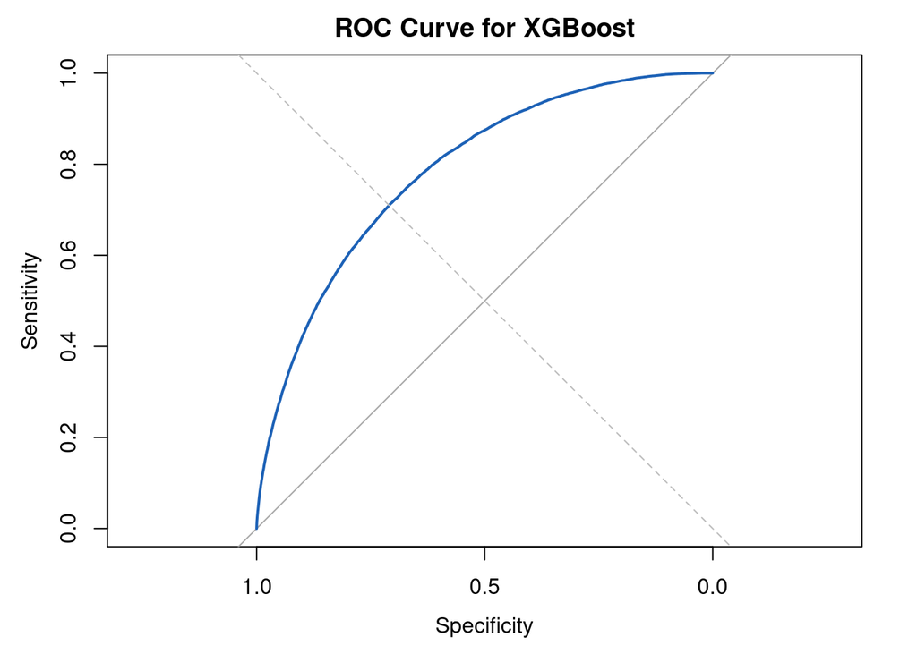

```r
# Plot the ROC curve
plot(roc_obj, main="ROC Curve for XGBoost", col="#1c61b6", lwd=2)
abline(a=0, b=1, lty=2, col="gray")
```

```r
# Calculate log loss
log_loss <- -mean(train_labels * log(train_predictions_prob) + (1 - train_labels) * log(1 - train_predictions_prob))
cat("Log Loss:", log_loss, "\n")
```

```
## Log Loss: 0.561813
```

```r
# Prepare the features from the test set
test_features <- final_test_tbl_encoded

# Convert to DMatrix for xgboost
dtest <- xgb.DMatrix(data = as.matrix(test_features))

# Predict probabilities on the test set
predicted_probabilities <- predict(model_xgb, dtest)

# If you need binary predictions
# predicted_classes <- ifelse(predicted_probabilities > 0.5, 1, 0)

# Now, attach the SK_ID_CURR from x_test_tbl and combine with the predictions
prediction_tbl <- x_test_tbl %>%
  select(SK_ID_CURR) %>%
  mutate(TARGET = predicted_probabilities)  # Or use predicted_classes if you created it

# View the prediction table
head(prediction_tbl)
```

```
##   SK_ID_CURR    TARGET
## 1     100001 0.1997291
## 2     100005 0.3522939
## 3     100013 0.2739462
## 4     100028 0.3189130
## 5     100038 0.6393572
## 6     100042 0.3315983
```

```r
#write.csv(prediction_tbl, "submission_005.csv", row.names = FALSE)
```

> Kaggle here is .73384

> TARGET 282686 (91.9%)  
> 24825 ( 8.1%)

> Notice the difference in the last confusion matrix…

> The results of my confusion matrices before and after adjusting the class weights highlight an important trade-off in predictive modeling:

> Without Weighting:

> The model had a high overall accuracy, but it was mainly driven by its ability to predict the majority class correctly. The number of true positives (defaults correctly identified) was very low, resulting in a poor sensitivity/specificity balance. With Weighting:

> After weighting the minority class, the number of true positives increased significantly, suggesting improved model sensitivity. However, this has come at the cost of incorrectly classifying more of the majority class, which is reflected in a lower overall accuracy and a significant number of false positives (non-defaults incorrectly identified as defaults).

> The choice between these models depends on what is more critical for our application:

> If the cost of missing defaults (true positives) is higher, we might prefer the model with the minority class weighted, even though it has lower overall accuracy. If overall accuracy is more important, and false positives are more costly, we might prefer the model without the weighting.

> We will need to improve Feature Engineering: Perhaps using the bureau data will assist us. Hyperparameter Tuning: Adjust other parameters like gamma, min_child_weight, or max_delta_step to control the balance between bias and variance.

> Cost-sensitive Learning: Beyond scale_pos_weight, we can look into custom loss functions that penalize false negatives more than false positives.